# Bear Creek

Sadie Gill, Mark Tompkins

July 1, 2019

## Floodplain Modeling Details

**Data Source:**

[Scaled from a Deer Creek flow to floodplain area relationship generated with a 1D HEC-RAS hydraulic model](https://s3-us-west-2.amazonaws.com/cvpiahabitat-r-package/cvpia-sit-model-inputs/DRAFT+Deer+Creek+Hydraulic+Models+Tech+Memo+6-08-07.pdf)

No site-specific hydraulic modeling was available for this watershed. A flow to floodplain area relationship was generated for this watershed by scaling the flow to floodplain area relationship for Deer Creek based on hydrologic and geomorphic analyses. Flows and corresponding floodplain areas per unit length were calculated for this watershed as 25% of Deer Creek values based on the ratio of mean flow from December to June between this watershed and Deer Creek. Of the entire mapped 17.30 mile rearing extent in this watershed, 4.32 miles were classified as low gradient and 12.98 miles were classified as high gradient based on a geomorphic analysis. A scaling factor of 0.1 was applied to the area per unit length for the high gradient extent. No scaling factor was applied to the low gradient extent.

## Floodplain Data

| flow_cfs | FR_floodplain_acres | ST_floodplain_acres | watershed |
| --- | --- | --- | --- |
| 195.5014 | 0.0000000 | 0.0000000 | Bear Creek |
| 220.8912 | 0.2984411 | 0.2984411 | Bear Creek |
| 246.2810 | 0.8764541 | 0.8764541 | Bear Creek |
| 271.6708 | 1.3612654 | 1.3612654 | Bear Creek |
| 297.0606 | 1.8826763 | 1.8826763 | Bear Creek |

*…with 17 more rows*

## Floodplain Plot

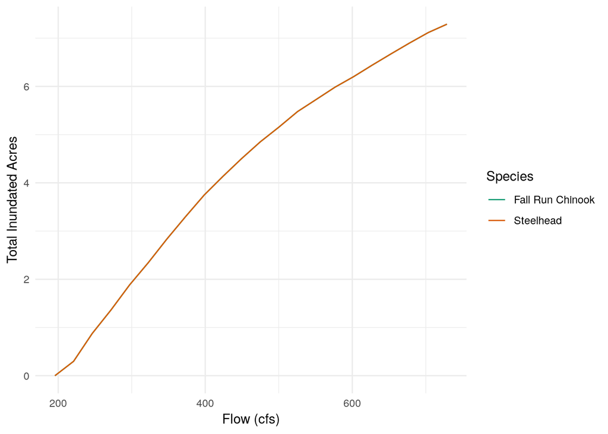